# Prosper Loan Data Visualization

## Introduction

### A loan is the lending of money by one or more individuals, organizations, or other entities to other individuals, organization, etc. The recipient (i.e. the borrower) incurs a debt, and is usually liable to pay interest on that debt until it is repaid, and also to repay the principal amount borrowed.This work is provided from Loan Data from Prosper which consist of 113,937 loans with 81 variables, last updated on 03/11/2014. From the 81 variables, only some variables of interest were selected.

### Most loans borrowers have C credit grade when they opened a loan. We can see how almost the same amount of good and bad credit grade borrowers open a loan in Prosper Loan Company.

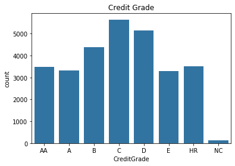

```python
color_base = sb.color_palette()[0]
sb.countplot(data=df_clean[df_clean.CreditGrade != 'Unknown'], x='CreditGrade', color = color_base, order = ['AA','A','B','C','D','E','HR','NC']);
plt.title('Credit Grade');
```

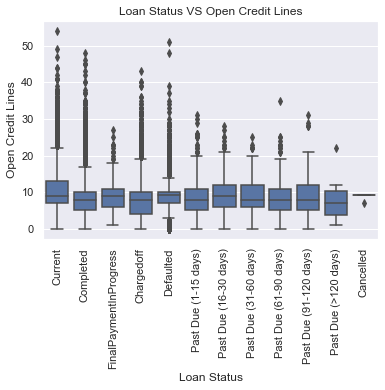

```python
color_base = sb.color_palette()[0]
sb.boxplot(data = df_clean, x = 'LoanStatus', y = 'OpenCreditLines',color = color_base, order = ['Current','Completed','FinalPaymentInProgress','Chargedoff','Defaulted','Past Due (1-15 days)',
                                                                   'Past Due (16-30 days)','Past Due (31-60 days)',
                                                                   'Past Due (61-90 days)','Past Due (91-120 days)','Past Due (>120 days)',
                                                                   'Cancelled'] );
plt.xticks(rotation=90);
plt.xlabel('Loan Status');
plt.ylabel('Open Credit Lines');
plt.title('Loan Status VS Open Credit Lines');
rcParams['figure.figsize'] = 11,20
sb.set(rc={'figure.figsize':(10,20)})
```

### The best borrowed rate which is below 0.20 falls within the completed status, final payment in process status, and current loans. It is interested to see that the entire past due loans are about the same rate.

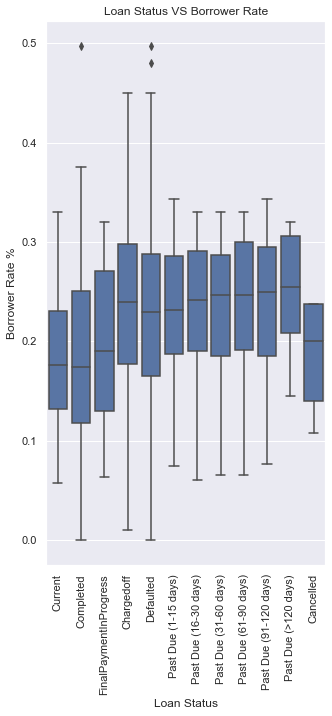

```python
color_base = sb.color_palette()[0]
sb.boxplot(data = df_clean, x = 'LoanStatus', y = 'BorrowerRate',color = color_base, order = ['Current','Completed','FinalPaymentInProgress','Chargedoff','Defaulted','Past Due (1-15 days)',
                                                                   'Past Due (16-30 days)','Past Due (31-60 days)',
                                                                   'Past Due (61-90 days)','Past Due (91-120 days)','Past Due (>120 days)',
                                                                   'Cancelled'] );
plt.xticks(rotation=90);
plt.xlabel('Loan Status');
plt.ylabel('Borrower Rate %');
plt.title('Loan Status VS Borrower Rate');
sb.set(rc={'figure.figsize':(10,20)})
```

### We can see how the best credit grade (AA) has the least APR percentage. The plot moves up on the APR as the credit grade decrease. However, it is noticeable that not credit grade it has a better APR than the HR or E credit grades.

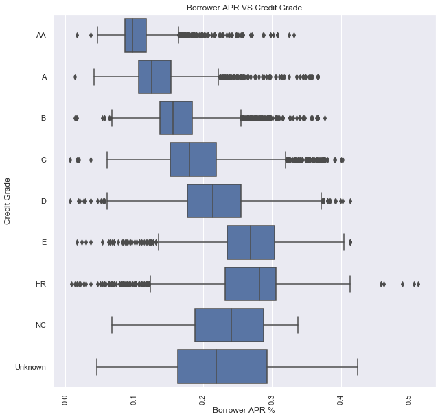

```python
color_base = sb.color_palette()[0]
sb.boxplot(data = df_clean, x = 'BorrowerAPR', y = 'CreditGrade', color = color_base, order = ['AA','A','B','C','D','E','HR','NC','Unknown']);
plt.xticks(rotation=90);
plt.xlabel('Borrower APR %');
plt.ylabel('Credit Grade');
plt.title('Borrower APR VS Credit Grade');
sb.set(rc={'figure.figsize':(10,10)})
```

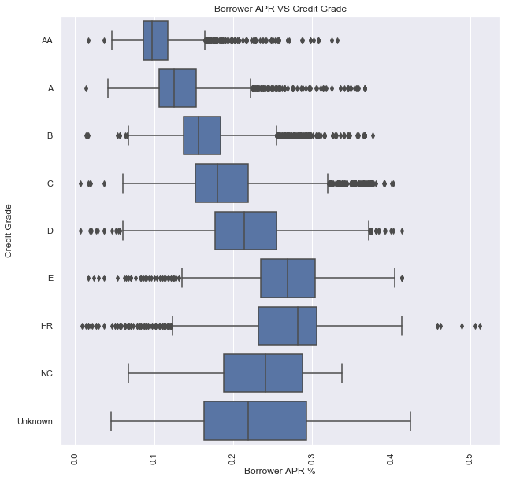

```python
color_base = sb.color_palette()[0]
sb.boxplot(data = df_clean, x = 'BorrowerAPR', y = 'CreditGrade', color = color_base, order = ['AA','A','B','C','D','E','HR','NC','Unknown']);
plt.xticks(rotation=90);
plt.xlabel('Borrower APR %');
plt.ylabel('Credit Grade');
plt.title('Borrower APR VS Credit Grade');
sb.set(rc={'figure.figsize':(10,30)})
```